# Notebook report

## Boosting for regression trees

Lets start by simulating some data …

```r
boost_simdat <- simulater(
  sequ = "x2 0 100",
  grid = "x1 0 6.5 0.1",
  form = "y = 10 + x1 * cos(pi * x1) - 0.1 * x2",
  seed = 1234
)
summary(boost_simdat, dec = 4)
```

```
Simulation
Simulations: 66
Random seed: 1234
Sim data   : boost_simdat
Grid search: x1 0 6.5 0.1
Sequence   : x2 0 100
Formulas   :
    y = 10 + x1 * cos(pi * x1) - 0.1 * x2

Variables:
 variable n_obs    mean      sd     min     p25  median     p75      max
       x1    66  3.2500  1.9196  0.0000  1.6250  3.2500  4.8750   6.5000
       x2    66 50.0000 29.5329  0.0000 25.0000 50.0000 75.0000 100.0000
       y     66  5.2954  3.5165 -2.6965  3.0068  6.4497  7.8380  10.0000
```

```r
register("boost_simdat")
```

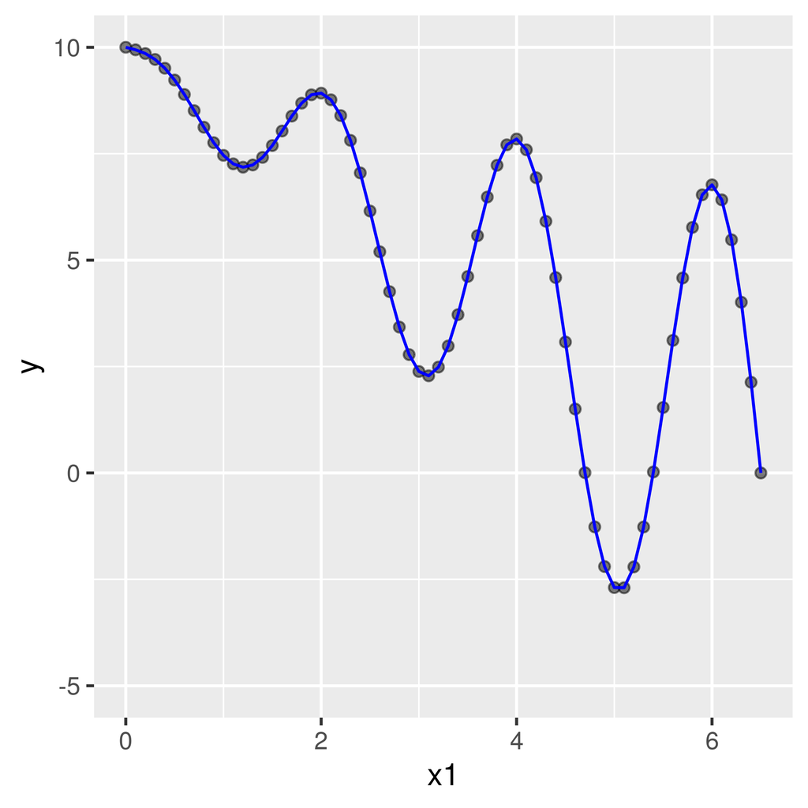

```r
visualize(
  boost_simdat,
  xvar = "x1",
  yvar = "y",
  type = "scatter",
  nrobs = -1,
  ylim = c(-5, 10),
  custom = TRUE
) +
  geom_line(data = boost_simdat, aes(x = x1, y = y), color = "blue")
```

Building a first (small) tree will, of course, not yield very accurate predictions. Add the predictions to the data set as `pred_tree1`

```r
result <- crtree(
  boost_simdat,
  rvar = "y",
  evar = "x1",
  type = "regression",
  cp = 0.1
)
summary(result, prn = TRUE)
```

```
Regression tree
Data                 : boost_simdat
Response variable    : y
Explanatory variables: x1
Complexity parameter : 0.1
Minimum observations : 2
Nr obs               : 66

node), split, n, deviance, yval
      * denotes terminal node

1) root 66 803.79550  5.2954260
  2) x1>=2.55 40 379.92060  3.3156880
    4) x1>=4.45 21 214.80490  1.8391160
      8) x1< 5.55 11  38.05545 -0.5621947 *
      9) x1>=5.55 10  43.54801  4.4805590 *
    5) x1< 4.45 19  68.72519  4.9476870 *
  3) x1< 2.55 26  25.90867  8.3411770 *
```

```r
plot(result, orient = "TD", width = "800px") %>% render()
```

[interactive chart not shown]

```r
pred <- predict(result, pred_data = boost_simdat)
boost_simdat <- store(boost_simdat, result, name = "resid_tree1")
print(pred, n = 10)
```

```
Classification and regression trees
Data                 : boost_simdat
Response variable    : y
Explanatory variables: x1
Prediction dataset   : boost_simdat
Rows shown           : 10 of 66

    x1 Prediction
 0.000      8.341
 0.100      8.341
 0.200      8.341
 0.300      8.341
 0.400      8.341
 0.500      8.341
 0.600      8.341
 0.700      8.341
 0.800      8.341
 0.900      8.341
```

```r
boost_simdat <- store(boost_simdat, pred, name = "pred_tree1")
```

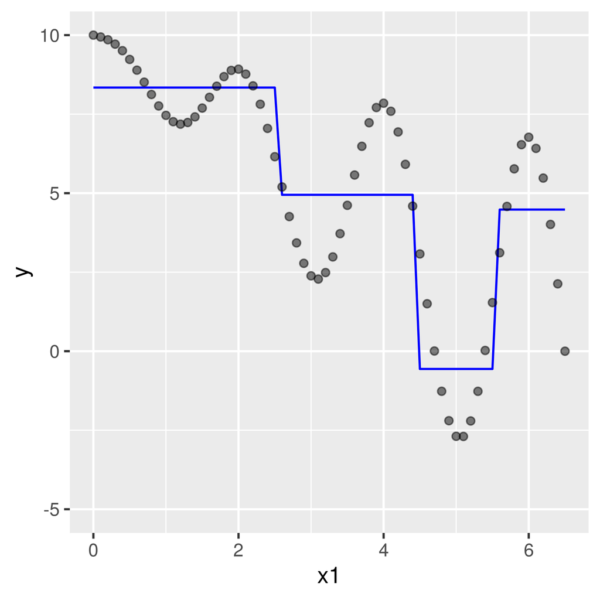

```r
visualize(
  boost_simdat,
  xvar = "x1",
  yvar = "pred_tree1",
  type = "line",
  ylim = c(-5, 10),
  labs = list(y = "y"),
  linecol = "blue",
  custom = TRUE
) +
  geom_point(data = boost_simdat, aes(x = x1, y = y), alpha = 0.5)
```

Now take the residuals from the first tree you estimated and use `resid_tree1` as the response variable to build a new tree. Generate predictions for this tree and add them to the data set as `pred_tree2`

```r
result <- crtree(
  boost_simdat,
  rvar = "resid_tree1",
  evar = "x1",
  type = "regression",
  cp = 0.1
)
summary(result, prn = TRUE)
```

```
Regression tree
Data                 : boost_simdat
Response variable    : resid_tree1
Explanatory variables: x1
Complexity parameter : 0.1
Minimum observations : 2
Nr obs               : 66

node), split, n, deviance, yval
      * denotes terminal node

 1) root 66 176.237300  0.00000000000000001345725
   2) x1>=6.35 2   2.271763 -3.41478100000000006630785 *
   3) x1< 6.35 64 149.915300  0.10671189999999999842295
     6) x1< 3.55 36  52.118540 -0.42614459999999998451869
      12) x1>=0.75 28  25.656410 -0.86657459999999997268816 *
      13) x1< 0.75 8   2.020821  1.11535999999999990706101 *
     7) x1>=3.55 28  74.432890  0.79181310000000004745146
      14) x1>=4.65 17  38.433150  0.06627358999999999333852
        28) x1< 5.35 7   5.742576 -1.19848299999999996501288 *
        29) x1>=5.35 10  13.655240  0.95160290000000002930136 *
      15) x1< 4.65 11  13.220650  1.91310099999999994047073 *
```

```r
pred <- predict(result, pred_data = boost_simdat)
boost_simdat <- store(boost_simdat, result, name = "resid_tree2")
print(pred, n = 10)
```

```
Classification and regression trees
Data                 : boost_simdat
Response variable    : resid_tree1
Explanatory variables: x1
Prediction dataset   : boost_simdat
Rows shown           : 10 of 66

    x1 Prediction
 0.000      1.115
 0.100      1.115
 0.200      1.115
 0.300      1.115
 0.400      1.115
 0.500      1.115
 0.600      1.115
 0.700      1.115
 0.800     -0.867
 0.900     -0.867
```

```r
boost_simdat <- store(boost_simdat, pred, name = "pred_tree2")
```

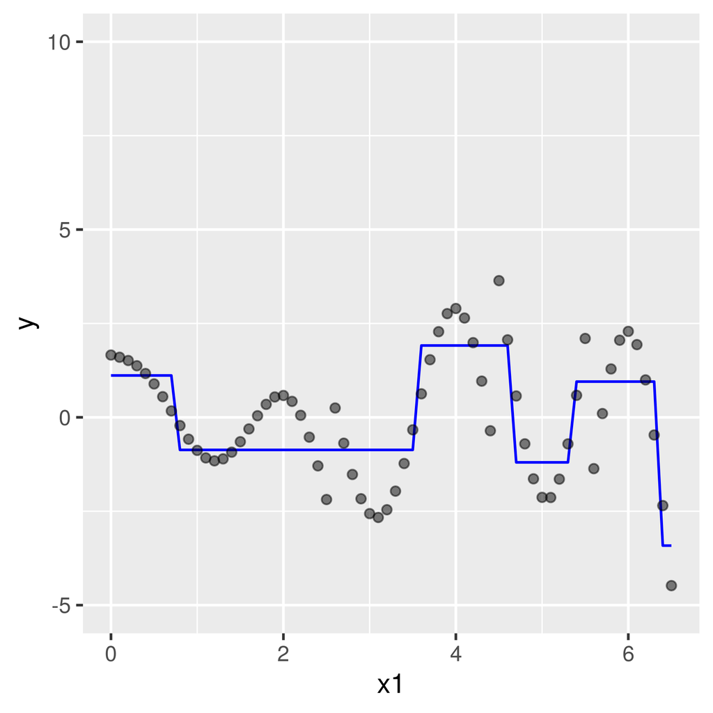

```r
visualize(
  boost_simdat,
  xvar = "x1",
  yvar = "pred_tree2",
  type = "line",
  ylim = c(-5, 10),
  labs = list(y = "y"),
  linecol = "blue",
  custom = TRUE
) +
  geom_point(data = boost_simdat, aes(x = x1, y = resid_tree1), alpha = 0.5)
```

Now take the residuals from the second tree you estimated and use `resid_tree2` as the response variable to build a new tree. Generate predictions for this tree and add them to the data set as `pred_tree3`

```r
result <- crtree(
  boost_simdat,
  rvar = "resid_tree2",
  evar = "x1",
  type = "regression",
  cp = 0.08
)
summary(result, prn = TRUE)
```

```
Regression tree
Data                 : boost_simdat
Response variable    : resid_tree2
Explanatory variables: x1
Complexity parameter : 0.08
Minimum observations : 2
Nr obs               : 66

node), split, n, deviance, yval
      * denotes terminal node

1) root 66 62.567460  0.00000000000000001345725
  2) x1>=2.35 42 48.795230 -0.20051150000000000916955
    4) x1< 3.35 10  7.792390 -0.85932169999999996612416 *
    5) x1>=3.35 32 35.306190  0.00536662699999999968231 *
  3) x1< 2.35 24  9.128567  0.35089520000000001820339
    6) x1< 1.55 16  2.752889  0.02077765000000000167324 *
    7) x1>=1.55 8  1.144753  1.01113000000000008427037 *
```

```r
pred <- predict(result, pred_data = boost_simdat)
boost_simdat <- store(boost_simdat, result, name = "resid_tree3")
print(pred, n = 10)
```

```
Classification and regression trees
Data                 : boost_simdat
Response variable    : resid_tree2
Explanatory variables: x1
Prediction dataset   : boost_simdat
Rows shown           : 10 of 66

    x1 Prediction
 0.000      0.021
 0.100      0.021
 0.200      0.021
 0.300      0.021
 0.400      0.021
 0.500      0.021
 0.600      0.021
 0.700      0.021
 0.800      0.021
 0.900      0.021
```

```r
boost_simdat <- store(boost_simdat, pred, name = "pred_tree3")
```

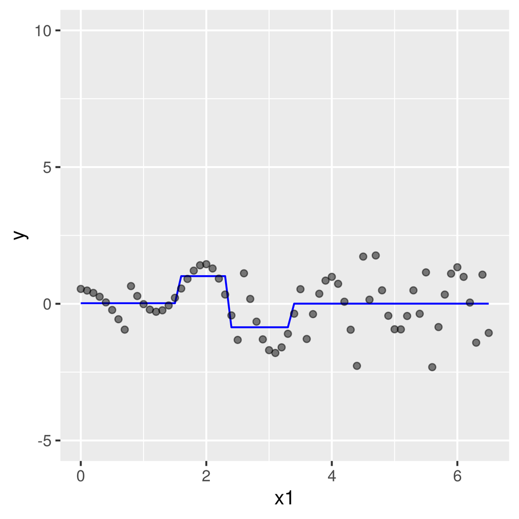

```r
visualize(
  boost_simdat,
  xvar = "x1",
  yvar = "pred_tree3",
  type = "line",
  ylim = c(-5, 10),
  labs = list(y = "y"),
  linecol = "blue",
  custom = TRUE
) +
  geom_point(data = boost_simdat, aes(x = x1, y = resid_tree2), alpha = 0.5)
```

The final prediction, assuming a learning rate of 1, is simply the sum of the predictions from the three trees we estimated.

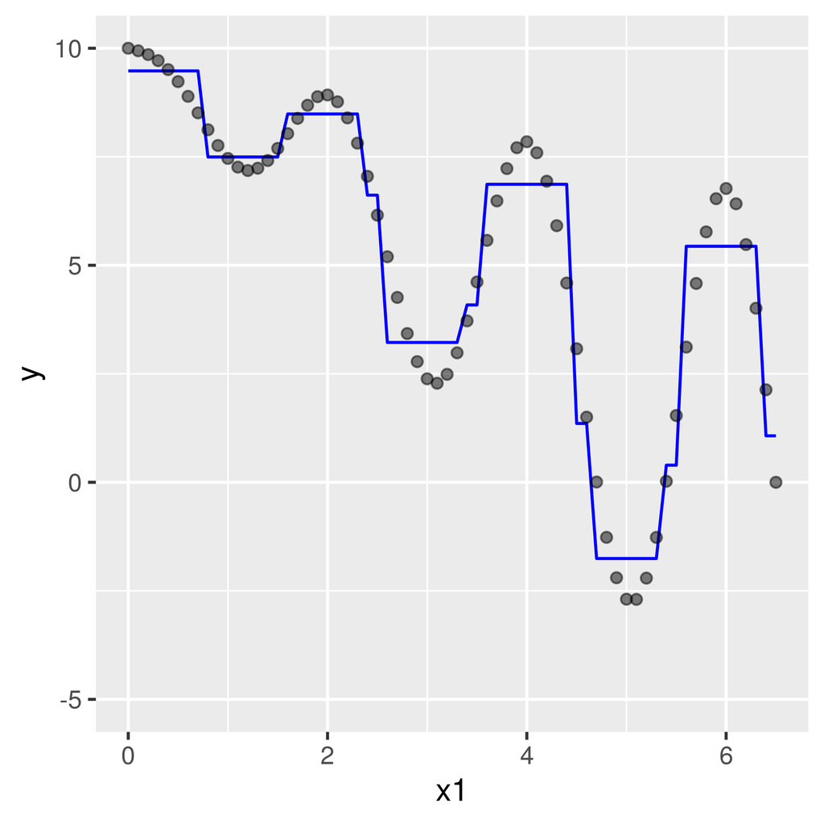

```r
boost_simdat <- mutate(
  boost_simdat,
  prediction = pred_tree1 + pred_tree2 + pred_tree3
)

visualize(
  boost_simdat,
  xvar = "x1",
  yvar = "prediction",
  type = "line",
  ylim = c(-5, 10),
  labs = list(y = "y"),
  linecol = "blue",
  custom = TRUE
) +
  geom_point(data = boost_simdat, aes(x = x1, y = y), alpha = 0.5)
```

Learning rates are generally set well below 1 in practice, but, as you can tell from the plot below that would require building many more trees to get a good fit to the data. The upside of a smaller learning rate is that we are less likely to overfit

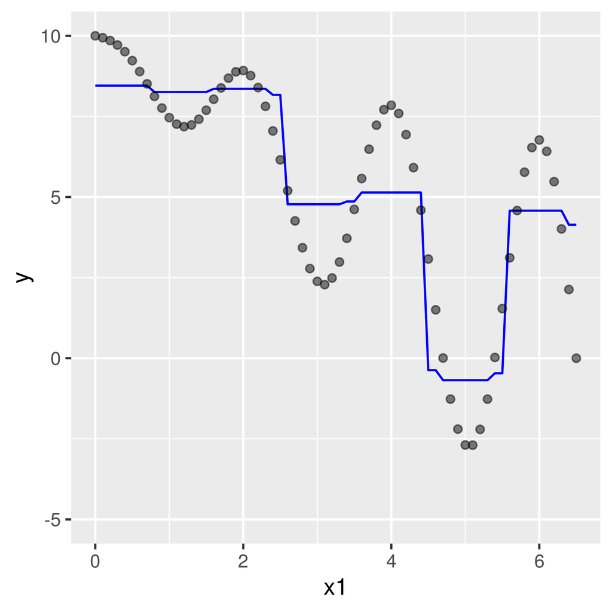

```r
boost_simdat <- mutate(
  boost_simdat,
  prediction = pred_tree1 + 0.1 * pred_tree2 + 0.1 * pred_tree3
)

visualize(
  boost_simdat,
  xvar = "x1",
  yvar = "prediction",
  type = "line",
  ylim = c(-5, 10),
  labs = list(y = "y"),
  linecol = "blue",
  custom = TRUE
) +
  geom_point(data = boost_simdat, aes(x = x1, y = y), alpha = 0.5)
```

Can XGBoost capture this patter well?

```r
result <- gbt(
  boost_simdat,
  rvar = "y",
  evar = "x1",
  type = "regression",
  early_stopping_rounds = 3,
  seed = 1234
)
summary(result, prn = TRUE)
```

```
Gradient Boosted Trees (XGBoost)
Type                 : Regression
Data                 : boost_simdat
Response variable    : y
Explanatory variables: x1
Max depth            : 6
Learning rate (eta)  : 0.3
Min split loss       : 0
Min child weight     : 1
Sub-sample           : 1
Nr of rounds (trees) : 100
Early stopping rounds: 3
Seed                 : 1234
Nr obs               : 66

Iteration history:

...
Stopping. Best iteration:
```

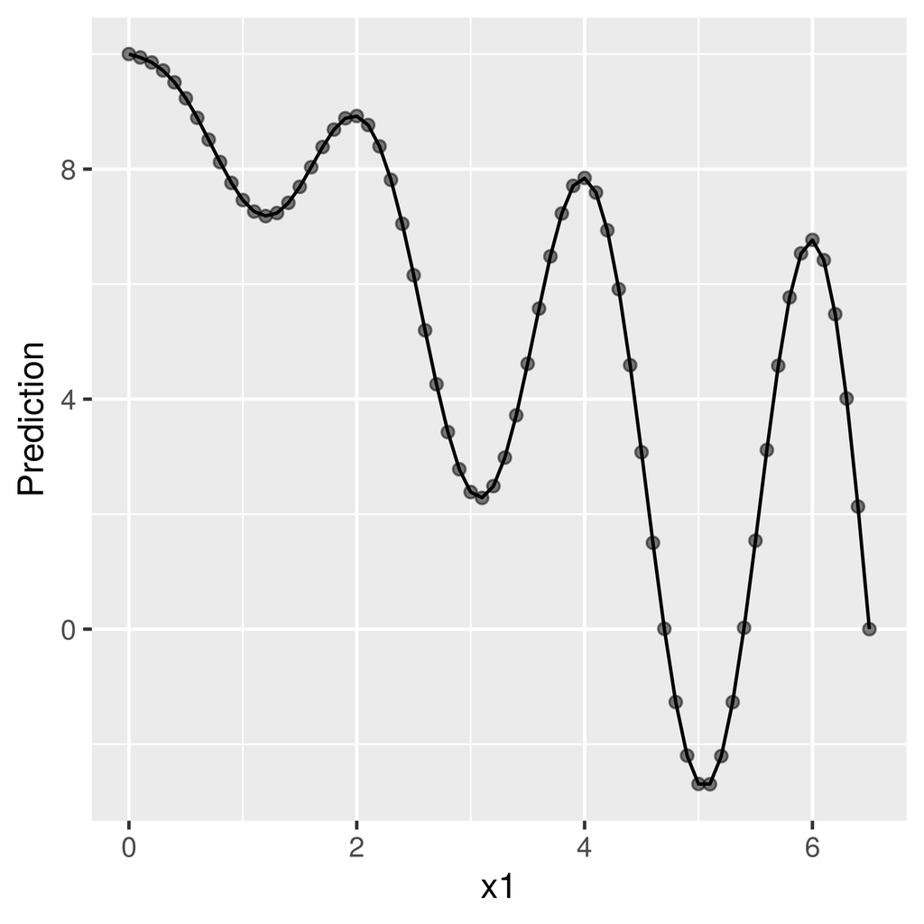

```r
pred <- predict(result, pred_data = boost_simdat)
plot(pred, xvar = "x1", custom = TRUE) +
  geom_point(data = boost_simdat, aes(x = x1, y = y), alpha = 0.5)
```

```r
print(pred, n = 10)
```

```
Gradiant Boosted Trees
Data                 : boost_simdat
Response variable    : y
Explanatory variables: x1
Prediction dataset   : boost_simdat
Rows shown           : 10 of 66

    x1 Prediction
 0.000      9.999
 0.100      9.942
 0.200      9.855
 0.300      9.713
 0.400      9.509
 0.500      9.231
 0.600      8.893
 0.700      8.509
 0.800      8.122
 0.900      7.761
```

```r
boost_simdat <- store(boost_simdat, pred, name = "pred_gbt")
```